# assignment

Catherine Rohner

2024-05-22

```r
if (!require("BiocManager", quietly = TRUE))
    install.packages("BiocManager")

BiocManager::install("bsseqData")
```

```r
suppressPackageStartupMessages({
  library(GenomicRanges)
  library(epiwraps)
  library(ggplot2)
  library(rGREAT)
  library(AnnotationHub)
  library(ensembldb)
  library(bsseq)
  library(BiocParallel)
  library(edgeR)
  library(DMRcate)
  library(rtracklayer)
  library(sechm)
  library(pheatmap)
  library(viridis)
  library(data.table)
})

set.seed(40)
```

```r
setwd("/Users/catherinerohner/ETH/Bioinformatics/assignment11")
list.files()
```

```
## [1] "assignment.html"   "assignment.Rmd"    "w11_practical"
## [4] "w11_practical.zip"
```

```r
options(timeout = 6000)
download.file("https://ethz-ins.org/content/w11_practical.zip", "w11_practical.zip")
dir.create("./w11_practical")
unzip("w11_practical.zip", exdir="./w11_practical")
```

```r
# Load the required RDS files
bs <- readRDS("./w11_practical/bs.rds")
dmrRanges <- readRDS("./w11_practical/dmr.rds")
genesChr22 <- readRDS("./w11_practical/genes_chr22.rds")

# Filter to get the top 5 DMRs
dmrRanges <- dmrRanges[order(dmrRanges$min_smoothed_fdr)[1:5]]
```

## Plot a heatmap of the methylation levels of the genes in top 5 DMR regions.

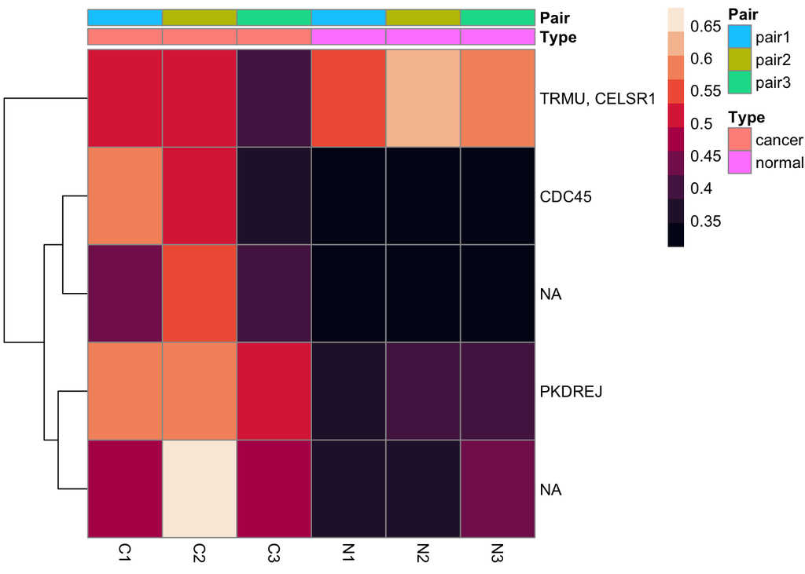

```r
# Get methylation levels
metPr <- bsseq::getMeth(bs, regions=dmrRanges, what="perRegion")
colnames(metPr) <- colnames(bs)
rownames(metPr) <- dmrRanges$overlapping.genes

# Filter out rows with NA values
metPr <- metPr[!is.na(rowSums(metPr)),]

# Plot heatmap
annotationCol <- as.data.frame(pData(bs))
rownames(annotationCol) <- colnames(metPr)
pheatmap::pheatmap(metPr,
                   cluster_rows=TRUE,
                   cluster_cols=FALSE,
                   annotation_col=annotationCol,
                   show_rownames = TRUE,
                   color=rocket(10))
```

## Run an enrichment analysis (rGREAT) of the genes within DMRs vs all genes of chromosome 22.

```r
# Prepare data for GREAT
# Load all genes of chromosome 22
allGenes <- genesChr22

# Get the gene names within the top 5 DMRs
dmrGenes <- unlist(tstrsplit(dmrRanges$overlapping.genes, split=", "))
dmrGenes <- dmrGenes[!is.na(dmrGenes)]
dmrGeneRanges <- genesChr22[genesChr22$gene_name %in% dmrGenes]

# Create GREAT job
job <- submitGreatJob(dmrGeneRanges, bg=allGenes, species="hg38")
```

```
## Note: On Aug 19 2019 GREAT released version 4 which supports hg38
## genome and removes some ontologies such pathways. submitGreatJob()
## still takes hg19 as default. hg38 can be specified by argument `genome
## = "hg38"`. To use the older versions such as 3.0.0, specify as
## submitGreatJob(..., version = "3"). Set argument `help` to `FALSE` to
## turn off this message.
```

```r
# Get enrichment table
enrichmentTable <- getEnrichmentTables(job)
```

[output not shown]

```r
head(enrichmentTable[[1]])
```

```
##           ID                                                        name
## 1 GO:0000049                                                tRNA binding
## 2 GO:0005509                                         calcium ion binding
## 3 GO:0016783                                  sulfurtransferase activity
## 4 GO:0016782 transferase activity, transferring sulfur-containing groups
## 5 GO:0043138                                 3'-5' DNA helicase activity
## 6 GO:0004930                         G-protein coupled receptor activity
##   Hyper_Total_Regions Hyper_Expected Hyper_Foreground_Region_Hits
## 1                   4    0.010796220                            2
## 2                  42    0.113360300                            3
## 3                  12    0.032388660                            2
## 4                  21    0.056680160                            2
## 5                   3    0.008097166                            1
## 6                  68    0.183535800                            2
##   Hyper_Fold_Enrichment Hyper_Region_Set_Coverage Hyper_Term_Region_Coverage
```

[output cut: 20 more lines]

## What is the enrichment analysis testing?

The enrichment analysis using rGREAT tests whether the genes within the top 5 differentially methylated regions (DMRs) are significantly associated with specific biological functions, pathways, or genomic features compared to all genes on chromosome 22. This analysis aims to identify whether certain gene ontology (GO) terms, pathways, or genomic annotations are overrepresented among the genes associated with the DMRs, suggesting that these biological processes or functions may be impacted by the observed methylation changes.

## Description of the Results

The enrichment analysis reveals significant associations between differentially methylated regions (DMRs) and specific biological functions. Notably, the term “tRNA binding” (GO:0000049) exhibits a very high fold enrichment of 185.25, indicating that genes related to tRNA binding are vastly overrepresented in the DMRs. This finding is statistically significant with a raw p-value of $3.27 \times 10^{-5}$, though the adjusted p-value is 0.138, suggesting a need for cautious interpretation.

Similarly, “calcium ion binding” (GO:0005509) shows a fold enrichment of 26.46 and a raw p-value of $8.31 \times 10^{-5}$, pointing to an overrepresentation of genes involved in calcium ion binding within the DMRs. The adjusted p-value here is 0.176.

Other terms such as “sulfurtransferase activity” (GO:0016783) and “transferase activity, transferring sulfur-containing groups” (GO:0016782) also display significant fold enrichments of 61.75 and 35.29, respectively, with raw p-values indicating notable enrichment, though their adjusted p-values suggest these findings should be interpreted with caution.

The term “3’-5’ DNA helicase activity” (GO:0043138) also shows a notable fold enrichment of 123.50 with a raw p-value of $8.08 \times 10^{-3}$. This indicates that genes involved in 3’-5’ DNA helicase activity are significantly overrepresented in the DMRs, which could suggest a potential impact of differential methylation on DNA repair and replication processes. However, the adjusted p-value is 1.0, indicating that this result might not be significant after adjusting for multiple testing.